# Statistical Interference Course Project

Tjeerd Luykx

Monday, July 20, 2015

### Overview:

In this document the exponential distribution in R is investigated and is compared with the Central Limit Theorem. The exponential distribution can be simulated in R with `rexp(n, lambda)` where `lambda` is the rate parameter. The mean of exponential distribution is `1/lambda` and the standard deviation is also `1/lambda`. `lambda = 0.2` is set for all of the simulations. The distribution of averages of 40 exponentials is investigated. Note that a thousand simulations will be done in this project.

The document is created for the Coursera Statistical Interference course. As stated in the course project requirements, the document aims to give an answer to the following:

> Illustrate via simulation and associated explanatory text the properties of the distribution of the mean of 40 exponentials. You should: 1. Show the sample mean and compare it to the theoretical mean of the distribution. 2. Show how variable the sample is (via variance) and compare it to the theoretical variance of the distribution. 3. Show that the distribution is approximately normal.

### Simulations:

In the code chunk below the simulation method is defined. Constants are assigned and the seed is set to create reproducibility. The histogram displays the exponential distribution.

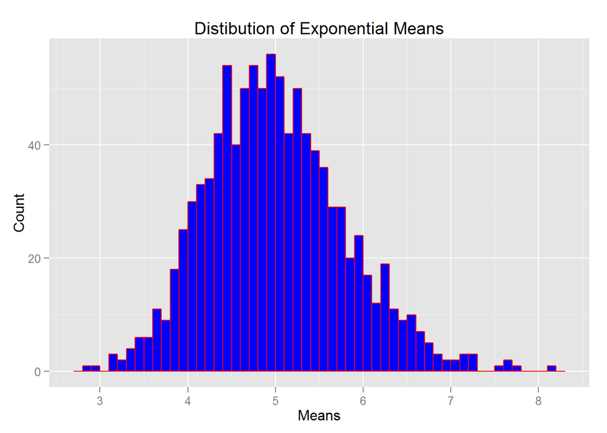

```r
library(ggplot2)
# Assign constants of lamda, number of tests and number of sims
lambda <- 0.2
n <- 40
SimNum <- 1000

# Setting seed to create reproducibility
set.seed(123456789)

# Construct rexp sim and format in to matrix and format data frame from means
ExpDist <- matrix(data=rexp(n = n * SimNum, rate = lambda), nrow=SimNum)
ExpDistMeans <- data.frame(Means = apply(X = ExpDist, MARGIN = 1, FUN = mean))

# Create histogram to display distribution of means
ggplot(data = ExpDistMeans, aes(x = Means)) +
        geom_histogram(binwidth=0.1, col="red", fill="blue") +
        labs(title="Distibution of Exponential Means") +
        labs(x="Means", y="Count") +
        scale_x_continuous(breaks=round(seq(min(ExpDistMeans$Means), max(ExpDistMeans$Means), by=1)))
```

### Sample Mean versus Theoretical Mean:

The average sample mean of 1000 simulations with 40 randomly sampled exponential distributions is calculated as:

```r
samplemean <- mean(ExpDistMeans$Means)

# The average sample mean regarding the distribution of the mean of 40 exponentials is centered at:
samplemean
```

```
## [1] 5.005439
```

The theoretical expected mean of an exponential distribution with rate `lambda` is equal to:

$\mu = \frac{1}{lambda}$

For `lambda = 0.2` that is:

```r
mu1 <- 1/0.2 ; mu1
```

```
## [1] 5
```

By means of calculation is has been shown that the sample mean and theoretical mean are different but almost equal.

### Sample Variance versus Theoretical Variance:

The average sample variance and standard deviation of 1000 simulations with 40 randomly sampled exponential distributions are calculated as:

```r
samplesd <- sd(ExpDistMeans$Means)
samplevar <- var(ExpDistMeans$Means)

# The average sample variance regarding the distribution of the mean of 40 exponentials is:
samplevar
```

```
## [1] 0.6203113
```

The theoretical standard deviation $\sigma$ of exponential distribution with rate $\lambda$ and sample size $n$ is:

$\sigma = \frac{1/\lambda}{\sqrt{n}}$

The variance is equal to the squared standard deviation:

$\sigma^2$

```r
# Theoretical standard deviation and variance of an exponential distribution:
sd1 <- 1/lambda/sqrt(n)
var1 <- sd1^2
var1
```

```
## [1] 0.625
```

Also for the variance the the sample result is different than the theoritical result. The difference is incremental.

### Distribution:

By using ggplot a normal distribution is displayed and compared to the reported exponential distribution:

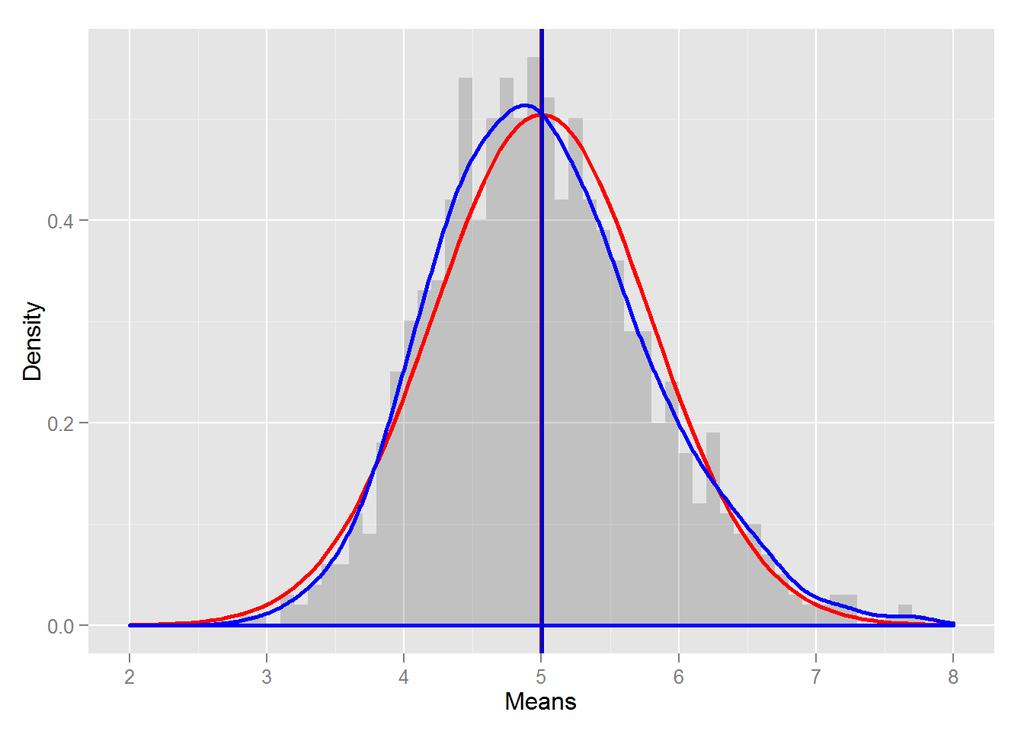

```r
# Graph displaying a normal distribution and the reported exponential distribution.
ggplot(data = ExpDistMeans, aes(x = Means)) +
  geom_histogram(binwidth=0.1, aes(y=..density..), alpha=0.2) +
  stat_function(fun = dnorm, arg = list(mean = mu1 , sd = sd1), colour = "red", size=1) +
  labs(x="Means", y="Density") +
  geom_vline(xintercept = mu1, size=1, colour="#CC0000") +
  geom_density(colour="blue", size=1) +
  geom_vline(xintercept = samplemean, size=1, colour="#0000CC") +
  scale_x_continuous(breaks=seq(mu1-3,mu1+3,1), limits=c(mu1-3,mu1+3))
```

The graph indicates that the exponential distribution is similar to that of the normal distribution. The expononential distribution overlaps the normal and has similar characteristics in kurtosis and skewness. Note that they are not exactly equal.

### Appendix:

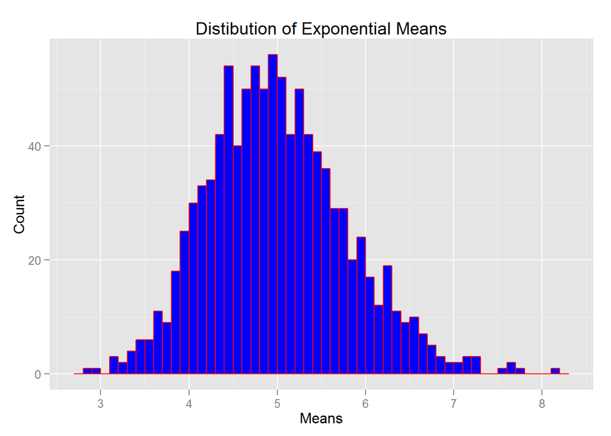

```r
# Assign constants of lamda, number of tests and number of sims
lambda <- 0.2
n <- 40
SimNum <- 1000

# Setting seed to create reproducibility
set.seed(123456789)

# Construct rexp sim and format in to matrix and format data frame from means
ExpDist <- matrix(data=rexp(n = n * SimNum, rate = lambda), nrow=SimNum)
ExpDistMeans <- data.frame(Means = apply(X = ExpDist, MARGIN = 1, FUN = mean))

# Create histogram to display distribution of means
ggplot(data = ExpDistMeans, aes(x = Means)) +
        geom_histogram(binwidth=0.1, col="red", fill="blue") +
        labs(title="Distibution of Exponential Means") +
        labs(x="Means", y="Count") +
        scale_x_continuous(breaks=round(seq(min(ExpDistMeans$Means), max(ExpDistMeans$Means), by=1)))
```

```r
samplemean <- mean(ExpDistMeans$Means)

# The average sample mean regarding the distribution of the mean of 40 exponentials is centered at:
samplemean
```

```
## [1] 5.005439
```

```r
# The theoretical expected mean of an exponential distribution with rate 0.2 is equal to:
mu1 <- 1/0.2 ; mu1
```

```
## [1] 5
```

```r
samplesd <- sd(ExpDistMeans$Means)
samplevar <- var(ExpDistMeans$Means)

# The average sample variance regarding the distribution of the mean of 40 exponentials is:
samplevar
```

```
## [1] 0.6203113
```

```r
sd1 <- 1/lambda/sqrt(n)

# The theoretical variance $\sigma^2$ of exponential distribution with rate $\lambda$ and sample size $n$ is:
var1 <- sd1^2
var1
```

```
## [1] 0.625
```

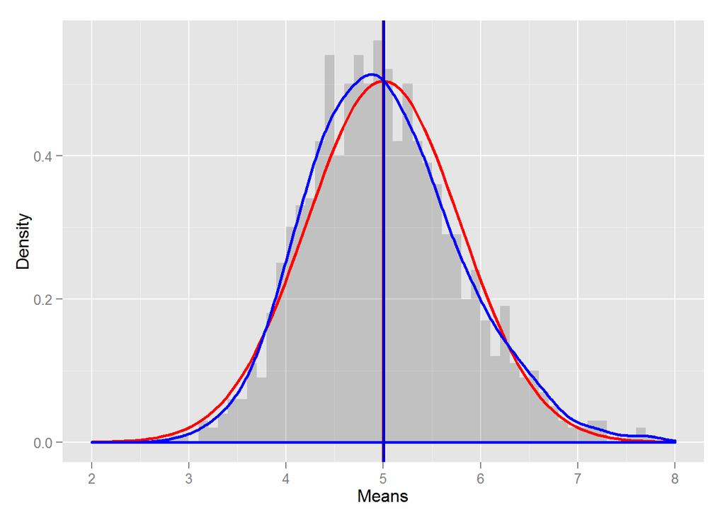

```r
# Graph displaying a normal distribution and the reported exponential distribution.
ggplot(data = ExpDistMeans, aes(x = Means)) +
  geom_histogram(binwidth=0.1, aes(y=..density..), alpha=0.2) +
  stat_function(fun = dnorm, arg = list(mean = mu1 , sd = sd1), colour = "red", size=1) +
  labs(x="Means", y="Density") +
  geom_vline(xintercept = mu1, size=1, colour="#CC0000") +
  geom_density(colour="blue", size=1) +
  geom_vline(xintercept = samplemean, size=1, colour="#0000CC") +
  scale_x_continuous(breaks=seq(mu1-3,mu1+3,1), limits=c(mu1-3,mu1+3))
```